# Sampling Distributions for Proportions

## Bernoulli Random Variable

A **bernoulli** random variable is defined as having two outcomes ("success", or "failure"): $$ f(y)=\left\{\begin{array}{ll} 1 & \text { success } \\ 0 & \text { failure } \end{array}\right. $$

where $p$ is the probability of achieving a successful outcome. Therefore: $$P(Y=1) = p$$ We let $q$ be the probability of a "failure" outcome: $$P(Y=0) = q$$ Since there are only two outcomes: $$q = 1 - p$$

We can denote a bernoulli random variable as $Y$, where $Y$ has a single parameter, $p$.

```python
import numpy as np
from scipy.stats import bernoulli
```

```python
p = 0.25
```

```python
Y = bernoulli(p=p)
```

We can perform a single trial of this bernoulli random variable and get an outcome (either 1, for success, or 0 for failure).

```python
np.random.seed(0)
outcome = Y.rvs() # take a sample
print(outcome)
```

```
0
```

If we take multiple trials, and sum the outcomes, the resulting random variable is said to be **binomially distributed**.

## Binomial Random Variable

If we sample a bernoulli random variable $n$ times and take the sum, the resulting variable is itself a random variable, which we denote by $X$.

$$X = \sum_{i=1}^{n}{Y_i}$$

The binomially distributed random variable $X$ has the parameters $n$ and $p$.

For a single sample of the random variable $X$ (which we can denote with $X_i$, and which is itself $n$ sample of a bernoulli distributed random variable), we can calculate the *sample proportion* (denoted $\hat{p}$), which serves as an estimate of the *population proportion* $p$:
$$\hat{p} = \frac{\sum_{i=1}^{n}{Y_i}}{n}=\frac{X_i}{n}$$

The mean of a binomially distributed random variable is: $$E(X) = np$$

and the variance is: $$Var(X) = npq$$

I'm not going to into proofs here, but you can google why this is :)

## Notation Thus Far

Some notation to start us off with:

- $p$ is the population proportion. It is a fixed value.
- $n$ is the size of the random sample.
- $\hat{p}$ is the *sample* proportion. It varies based on the sample.
- $X_i$ represents the $i$th sample containing the outcomes of $n$ bernoulli trials.

```python
## create PMF for random bernoulli variable
# use our bernoulliy random variable and sample from it n times...
# ...creating a binomial random variable with parameters n and p
n = 100

# take a single sample of size n, call it X_0
X_0 = Y.rvs(size=n)

# calculate a sample proportion called p_hat
p_hat = sum(X_0) / n
print('p_hat = {}'.format(p_hat))
q_hat = 1 - p_hat
```

```
p_hat = 0.2
```

```python
import matplotlib.pyplot as plt
%matplotlib inline
```

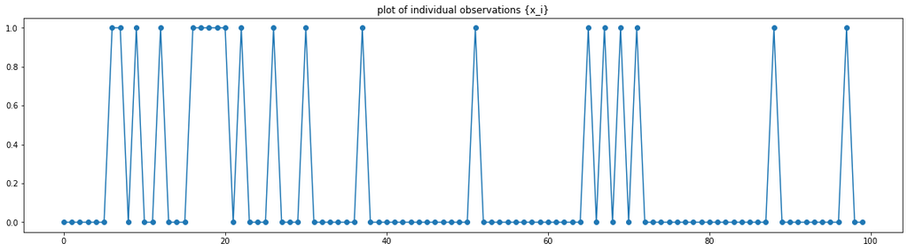

```python
fig = plt.figure(figsize=(20,5))
ax = fig.gca()
ax.plot(X_0, marker='o');
plt.title('plot of individual observations {x_i}');
```

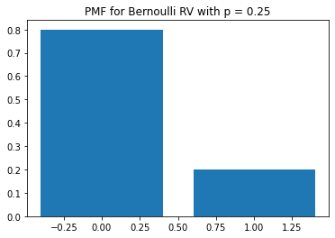

```python
# create an empirical P.M.F. (probability mass function) for the bernoulli random variable
# aka generate a PMF programmatically
plt.bar(x=[0,1], height=[q_hat, p_hat], )
plt.title('PMF for Bernoulli RV with p = {}'.format(p))
```

## PMF of a Binomially Distributed Random Variable

Construct the empirical PMF of a binomially distributed RV by taking repeated samples and plotting a histogram of the results.

```python
p = 0.25
n = 100
num_samples = 1000

Y = bernoulli(p) # setup RV with parameter p

# sample a bernoulli random variable num_samples times
X_i = []
for i in range(num_samples):
    sample = Y.rvs(size=n)
    X_i.append(sample)
```

```python
print(np.array(X_i).shape)
```

```
(1000, 100)
```

Now we have 1000 samples, each with 100 observations, where each observation is either a {1} or {0}.

```python
print(X_i[0])
```

```
[0 0 0 0 0 1 0 0 0 0 0 1 0 1 1 1 1 1 0 1 0 0 0 0 0 0 0 0 0 0 1 0 1 0 0 1 0
 0 1 0 0 1 0 1 0 1 0 0 1 0 1 1 1 0 0 0 0 0 1 0 1 0 0 0 0 0 0 0 0 0 0 0 0 0
 0 0 0 0 1 0 0 0 0 0 1 1 0 0 0 0 0 1 0 0 0 0 0 0 1 1]
```

A binomially distributed random variable represents the sum of $n$ outcomes of a bernoulli distributed random variable (see formulas above), so let's calculate the sum of each random sample.

```python
_X = []
for sample in X_i:
    _X.append(np.sum(sample))
```

Now let's plot a histogram of the sums.

```python
import seaborn as sns
```

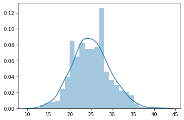

```python
sns.distplot(_X);
```

We can see that the distribution is centered around the mean of the binomially distributed random variable $X$, which, since it has parameters $n = 100$ and $p = 0.25$, is $E(X) = np = 25$.

Accordingly, for each sample, we can also calculate sample proportion $\hat{p}$, by taking the sum of each sample's individual observations, and dividing by the total size of the sample, $n$.

```python
# for one sample
sample = _X[0]
p_hat = sample / n
print(p_hat)
```

```
0.27
```

The true value for the population proportion $p$ is 0.25, but our individual estimate based on a single sample yielded 0.27.

We can calculate a sample proportion $\hat{p}$ for each sample, and plot the resulting distribution - this will the PMF of the binomial random variable X.

```python
_p_hat = []
for sample in _X:
    p_hat = sample / n
    _p_hat.append(p_hat)
```

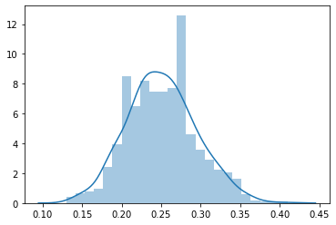

```python
sns.distplot(_p_hat);
```

We can see that the distribution is centered around roughly 0.25, which makes sense since our population proportion is 0.25.

This is what is called the **sampling distribution of sample proportions**.

We can see that each individual sample's sample proportion, can vary greatly from the mean of 0.25. This variation quantifies the amount that each sample proportion tends to vary with respect to the mean of 0.25 (the population proportion). We call this variation the **standard error**.

We can see how the standard error, or the shape of the distribution, changes depending on how big our sample size $n$ is. For instance, if we make $n = 1000$, and take `num_samples` samples and plot the distribution, we get:

```python
_p_hat_1000 = []
for i in range(num_samples):
    sample = Y.rvs(size=1000)
    p_hat = np.sum(sample) / 1000
    _p_hat_1000.append(p_hat)
```

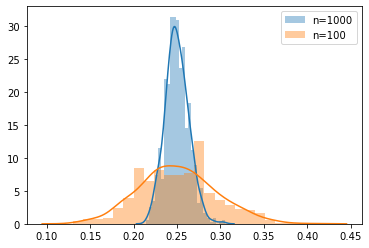

```python
sns.distplot(_p_hat_1000, label='n=1000', );
sns.distplot(_p_hat, label='n=100');
plt.legend();
```

We can see that the standard error (the standard deviation of the sampling distribution) has changed. The distribution where `n = 1000` is much tighter than the distribution for `n = 100`.

It means that samples taken when n is higher are typically more *accurate* than samples where n is lower. This "accuracy" is quantified via a **confidence interval**.

## Confidence Intervals for Sample Proportions

We can calculate a confidence interval in which we should expect the true population proportion to lie within, most of the time (95% of the time, typically).

This is kind of confusing, but not really, when you think about it. All we're saying is that typically, we only have one sample - one sample with $n$ observations in it.

What we want to know is, how accurate is this sample? How representative of the population is it?

Well, we can use the standard error to get a sense of the range of values around the sample proportion within which we should expect to find the true population proportion.

Let's calculate a confidence interval for one sample of our binomially distributed random variable where `n=100`.

```python
np.random.seed(0)

# take our sample
sample = Y.rvs(size=100)

# calculate the sample proportion, p_hat
p_hat = np.sum(sample) / 100

# calculate the 95% confidence interval
from statsmodels.stats.proportion import proportion_confint
ci = proportion_confint(np.sum(sample), nobs=100, alpha=1 - 0.95)

print('p_hat={}'.format(p_hat))
print('ci={}'.format(ci))
```

```
p_hat=0.2
ci=(0.12160144061839785, 0.2783985593816022)
```

For this sample, our sample proportion ended up being 0.2 - but our 95% confidence goes from 0.12 to 0.27.

If we were to do this same process 100 times, we can expect 95 of those confidence intervals generated to include the true population proportion of 0.25. *That's* what a confidence interval truly means.

(but colloquially, it is used to give an estimate of the range of values we can expect to find the true population proportion within)

## *Positivity Rate* of COVID-19

### using world COVID-19 data from John Hopkins University

Let's use a real world example to illustrate the usefulness of confidence intervals and the standard error.

For this example, I'll be using data from John Hopkins University for the number of confirmed cases and the number of tests administered. You can download the data from this url:

```python
data_url = 'https://github.com/owid/covid-19-data/blob/master/public/data/owid-covid-data.csv?raw=True'
```

A link to the full article can be found here: https://ourworldindata.org/covid-cases

The particular plot we'll be taking a look at is the plot for `COVID-19: Daily tests vs. Daily new confirmed cases per million`, which aims to give a sense of the amount of testing done per country on a any given day (as a rolling 7-day average), and also the daily new confirmed cases (as a rolling 7-day average). Both are normalized per one million tests/people.

Let's display the plot here:

```python
from IPython.display import IFrame, HTML
IFrame(
    src='https://ourworldindata.org/grapher/covid-19-daily-tests-vs-daily-new-confirmed-cases-per-million?tab=chart&stackMode=absolute&time=2021-02-03&country=&region=World',
    width=750,
    height=750,
)
```

[interactive chart not shown]

The diagonal lines represents the `positivity rate`, or, the ratio of the number of tests that come back as positive, to the total number of tests administered. You can read more about this graph here: https://ourworldindata.org/coronavirus-testing#the-positive-rate-a-crucial-metric-for-understanding-the-pandemic

The positivity rate, as I understand it, is a proxy for the true prevalence rate of a the population. If one had an unlimited number of tests, and it was possible to test every single individual in a given population (such as a country) all at once - then you would know the true prevalence rate of COVID-19 for that country at that moment in time. However, this is in practice, obviously not feasible, so I assume they rely on the `positivity rate` as some kind of a proxy for the true prevalence rate.

The `positivity rate` is analagous to $\hat{p}$ in our example above. To calculate it, we take a sample of $n$ tests, count the number of "successes" (or positive results), and take the ratio - that's our sample proportion, or $\hat{p}$.

Because the `positivity rate` is calculated from a sample - we can also calculate the **standard error** for our sample, and thus, we can also calculate a 95% confidence interval for the true population proportion (i.e. prevalence rate).

We can download the data using `pandas` and the following url:

```python
# append ?raw=True at the end of the URL
url_data = 'https://github.com/owid/covid-19-data/blob/master/public/data/owid-covid-data.csv?raw=True'
```

```python
import pandas as pd
```

```python
df = pd.read_csv(url_data, index_col=0)
```

```python
df.head()
```

| iso_code | continent | location | date | total_cases | new_cases | new_cases_smoothed | total_deaths | new_deaths | new_deaths_smoothed | total_cases_per_million | ... | gdp_per_capita | extreme_poverty | cardiovasc_death_rate | diabetes_prevalence | female_smokers | male_smokers | handwashing_facilities | hospital_beds_per_thousand | life_expectancy | human_development_index |
| --- | --- | --- | --- | --- | --- | --- | --- | --- | --- | --- | --- | --- | --- | --- | --- | --- | --- | --- | --- | --- | --- |
| AFG | Asia | Afghanistan | 2020-02-24 | 1.0 | 1.0 | NaN | NaN | NaN | NaN | 0.026 | ... | 1803.987 | NaN | 597.029 | 9.59 | NaN | NaN | 37.746 | 0.5 | 64.83 | 0.511 |
| AFG | Asia | Afghanistan | 2020-02-25 | 1.0 | 0.0 | NaN | NaN | NaN | NaN | 0.026 | ... | 1803.987 | NaN | 597.029 | 9.59 | NaN | NaN | 37.746 | 0.5 | 64.83 | 0.511 |
| AFG | Asia | Afghanistan | 2020-02-26 | 1.0 | 0.0 | NaN | NaN | NaN | NaN | 0.026 | ... | 1803.987 | NaN | 597.029 | 9.59 | NaN | NaN | 37.746 | 0.5 | 64.83 | 0.511 |
| AFG | Asia | Afghanistan | 2020-02-27 | 1.0 | 0.0 | NaN | NaN | NaN | NaN | 0.026 | ... | 1803.987 | NaN | 597.029 | 9.59 | NaN | NaN | 37.746 | 0.5 | 64.83 | 0.511 |
| AFG | Asia | Afghanistan | 2020-02-28 | 1.0 | 0.0 | NaN | NaN | NaN | NaN | 0.026 | ... | 1803.987 | NaN | 597.029 | 9.59 | NaN | NaN | 37.746 | 0.5 | 64.83 | 0.511 |

5 rows × 58 columns

```python
# create new columns
df['new_tests_smoothed_per_million'] = df['new_tests_smoothed_per_thousand'] * 1000
```

```python
cols_to_keep = [
    'date',
    'positive_rate',
    'new_cases_per_million',
    'new_cases_smoothed_per_million',
    'new_tests_per_thousand',
    'new_tests_smoothed_per_thousand',
    'new_tests_smoothed_per_million'
]
```

```python
# pick a date to look at data for
from datetime import datetime, timedelta
day_to_keep = '2021-02-03'
print('day_to_keep = {}'.format(day_to_keep_str))

# filter dataframe
dft = df[df['date']==day_to_keep_str]

# filter for columns
dft = dft[cols_to_keep]

# drop null values
dft = dft.dropna(subset=['positive_rate'])
```

[output not shown]

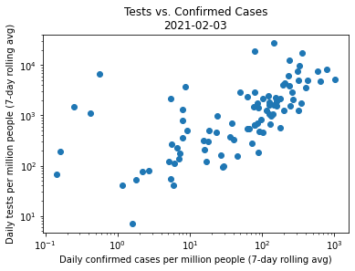

```python
x = dft['new_cases_smoothed_per_million'].values
y = dft['new_tests_smoothed_per_million'].values
plt.scatter(x, y);
ax = plt.gca()
ax.set_yscale('log')
ax.set_xscale('log')
plt.xlabel('Daily confirmed cases per million people (7-day rolling avg)')
plt.ylabel('Daily tests per million people (7-day rolling avg)')
plt.title('Tests vs. Confirmed Cases\n{}'.format(day_to_keep_str));
```

Let's look at a country with a low number of daily tests vs. a country with a high number of daily tests.

```python
iso_max = dft['new_tests_smoothed_per_million'].idxmax()
tests_max = dft.loc[iso_max, 'new_tests_smoothed_per_million']
print(iso_max, tests_max)
```

```
CYP 27171.0
```

```python
iso_min = dft['new_tests_smoothed_per_million'].idxmin()
tests_min = dft.loc[iso_min, 'new_tests_smoothed_per_million']
print(iso_min, tests_min)
```

```
COD 6.999999999999999
```

Now let's calculate the 95% confidence interval for each country.

```python
pos_rate_max, cases_max, tests_max = dft.loc[iso_max, ['positive_rate','new_cases_smoothed_per_million','new_tests_smoothed_per_million']].values
ci_max = proportion_confint(count=cases_max, nobs=tests_max, alpha=1 - 0.95)
print(iso_max, pos_rate_max, ci_max)
```

```
CYP 0.005 (0.0044369594024268886, 0.006163680986222774)
```

```python
pos_rate_min, cases_min, tests_min = dft.loc[iso_min, ['positive_rate','new_cases_smoothed_per_million','new_tests_smoothed_per_million']].values
ci_min = proportion_confint(count=cases_min, nobs=tests_min, alpha=1 - 0.95)
print(iso_min, pos_rate_min, ci_min)
```

```
COD 0.24 (0.0, 0.5398525041953706)
```

The 95% confidence interval for Cypress (CYP) is quite narrow - 0.4% to 0.6%. Conversely, the 95% confidence interval for COD (Democratic Republic of the Congo) is a lot wider - from 0% to 53.9%!

What this means is that the *true* value of the prevalence rate for COVID-19 in Cypress is probably around 0.5% - we can be pretty confident in that! However we almost have no idea what the *true* prevalence rate in the D.R.C is - it could be that as much as half of the population is infected, or a quarter, or nearly 0!

It's interesting to note that the 95% CI for the D.R.C. includes 0 - this tells us that something is wrong, because we know that the true prevalence rate cannot be 0, since we have some positive tests in our sample. I believe this points to the invalidity of our test, due to some assumptions not being satisfied.

Namely, the assumption for the **normal approximation to the binomial** is probably not satisfied. You can read up more on the requirements for the central limit theorem as it applies to binomially distributed data here: https://online.stat.psu.edu/stat500/lesson/4/4.2/4.2.2 but the gist is that, if a sample's sample size $n$ is too low, or the population proportion $p$ is too high or low, then the assumption that the sampling distribution of the sample proportion follows a normal distribution won't be satisfied, and we cannot therefore calculate things like a 95% confidence interval (well, we can, with boot-strapping, but that's a topic for another day...).

Let's take a look at another country that (hopefully) satifies the condition that $np \geq 5$.

```python
dft['new_tests_smoothed_per_million'].nsmallest()
```

```
iso_code
COD     7.0
NGA    40.0
UGA    40.0
SSD    52.0
ETH    54.0
Name: new_tests_smoothed_per_million, dtype: float64
```

```python
iso_nga = 'NGA'
tests_nga = dft.loc[iso_nga, 'new_tests_smoothed_per_million']
print(iso_nga, tests_nga)
```

```
NGA 40.0
```

Nigeria is the second lowest tester for this day (as a 7-day rolling average). Let's see if it satisfies the assumption required to approximate the sampling distribution of the proportion with a normal distribution...

Check for assumption that $np \geq 5$

```python
print('pos_rate_nga * tests_nga = {}'.format(pos_rate_nga * tests_nga))
print('{} >= 5: {}'.format(pos_rate_nga * tests_nga, pos_rate_nga * tests_nga >= 5))
```

```
pos_rate_nga * tests_nga = 5.96
5.96 >= 5: True
```

The assumption checks out.

```python
pos_rate_nga, cases_nga, tests_nga = dft.loc[iso_nga, ['positive_rate','new_cases_smoothed_per_million','new_tests_smoothed_per_million']].values
ci_nga = proportion_confint(count=cases_nga, nobs=tests_nga, alpha=1 - 0.95)
print(iso_nga, pos_rate_nga, ci_nga)
```

```
NGA 0.149 (0.037799558434258196, 0.25775044156574184)
```

We could feel more comfortable using this confidence interval rather than the one for the D.R.C., as our base assumption is satisfied in the case of Nigeria, whereas it is not for the D.R.C.